# Single cell analysis: Example

QuantBio

Last compiled on January 10, 2022

# 1 - Quality control and standardization file (QCStanAnn)

This is a general script to perform quality control and standardization of single cell RNA-seq datasets.

> *NOTE:* Make sure the data is the unedited seurat file.

```r
### First the seurat obect
bassez1 <- readRDS(file=params$qcs_dir_seurat)

### Change ident to original idents
Idents(bassez1)<-bassez1@meta.data[,params$qcs_indent_var]
```

## 1.1 - Quality Control

### Remove low quality cells

Remove dead cells, doublets, and cells with low molecule counts Examine the following 3 parameters:

1. `nFeature_RNA` is the number of genes detected in each cell.
2. `nCount_RNA` is the total number of molecules detected within a cell
3. `percent.mt` is the percent of features that are mitochondrial genes

**NOTE**

There are several things to consider. For one, a much higher number of gene counts or molecule counts may indicate that there are doublets, especially, in droplet based scRNA-seq data like 10X. This however is smart-seq, which is not droplet based. However, the caveat with smartseq is that it tends to capture a higher number of mitochondrial genes (i.e. dead cells).

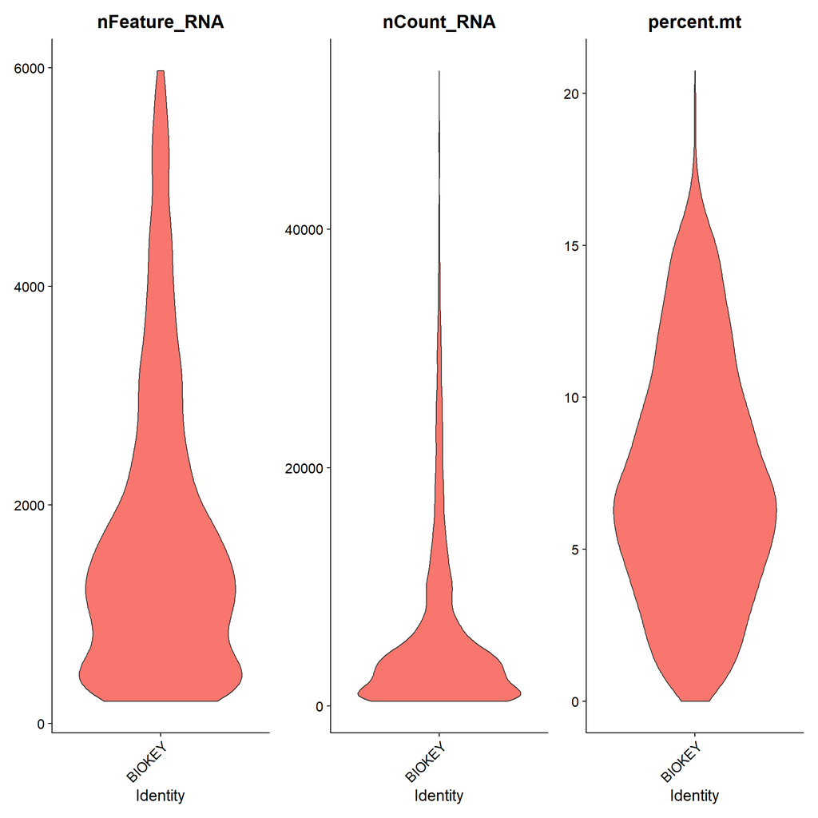

```r
### add mito.gene % in meta.data
bassez1[["percent.mt"]] <- PercentageFeatureSet(object = bassez1, pattern = "^MT|^mt")

### Plot the three parameters mentioned above
VlnPlot(bassez1,
        pt.size = 0,
        features = c("nFeature_RNA", "nCount_RNA", "percent.mt"),
        ncol = 3)
```

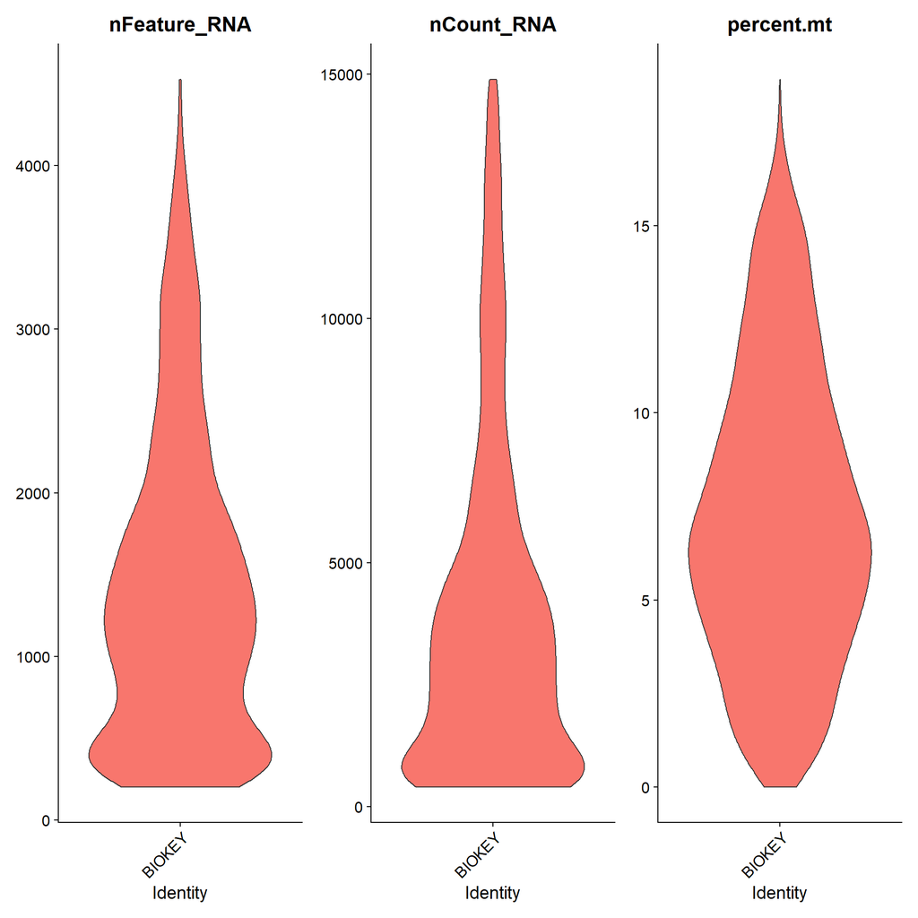

```r
### Filter out cells that have QC metrics +/- away from 3*MAD:
### nFeature_RNA metric > 200-3*MAD(nFeature_RNA) and < median(nFeature_RNA)+3*MAD(nFeature_RNA)
### nCount_RNA < median(nCountRNA)+3*MAD(nCountRNA)
### percent.mt < median(percent.mt)+3*MAD(percent.mt)
bassez1 <- subset(x = bassez1,
                  subset = nFeature_RNA > max(params$qcs_std_nFeature_RNA, median(bassez1@meta.data$nFeature_RNA, na.rm = TRUE) - 3*mad(bassez1@meta.data$nFeature_RNA, constant = 1.4826, na.rm = TRUE))
                  & nFeature_RNA < median(bassez1@meta.data$nFeature_RNA, na.rm = TRUE) + 3*mad(bassez1@meta.data$nFeature_RNA, constant = 1.4826, na.rm = TRUE)
                  & nCount_RNA < median(bassez1@meta.data$nCount_RNA, na.rm = TRUE) + 3*mad(bassez1@meta.data$nCount_RNA, constant = 1.4826, na.rm = TRUE)
                  & percent.mt < median(bassez1@meta.data$percent.mt, na.rm = TRUE) + 3*mad(bassez1@meta.data$percent.mt, constant = 1.4826, na.rm = TRUE)
                  )

### re-plot
VlnPlot(bassez1,
        pt.size=0,
        features = c("nFeature_RNA", "nCount_RNA", "percent.mt"),
        ncol = 3)
```

### Filter low count genes

```r
### Create the new seurat object
bassez1 <- CreateSeuratObject(bassez1@assays$RNA@counts, meta.data = bassez1@meta.data,
                              min.cells = 1, min.features = 1)
```

## 1.2 - Standardize

### Normalize the data

For data normalization, we use `NormalizeDatas()` that normalizes the feature expression measurements for each cell by the total expression, multiplies this by a scale factor (10,000 by default), and log-transforms the result. Normalized values are stored in **[[“RNA”]]@data**.

```r
bassez1 <- NormalizeData(bassez1,
                         normalization.method = "LogNormalize",
                         scale.factor = 10000)
```

### Regress out confounding variables

Calculate a subset of features that exhibit high cell-to-cell variation in the dataset (i.e, they are highly expressed in some cells, and lowly expressed in others). These genes help to highlight biological signal in single-cell datasets.

By default, `FindVariableFeatures` returns 2,000 features per dataset, but can be changed to any number. These may be used in downstream analysis, like PCA.

**NOTE**

This will be done for each tissue type individually, so make sure to run through them one at a time.

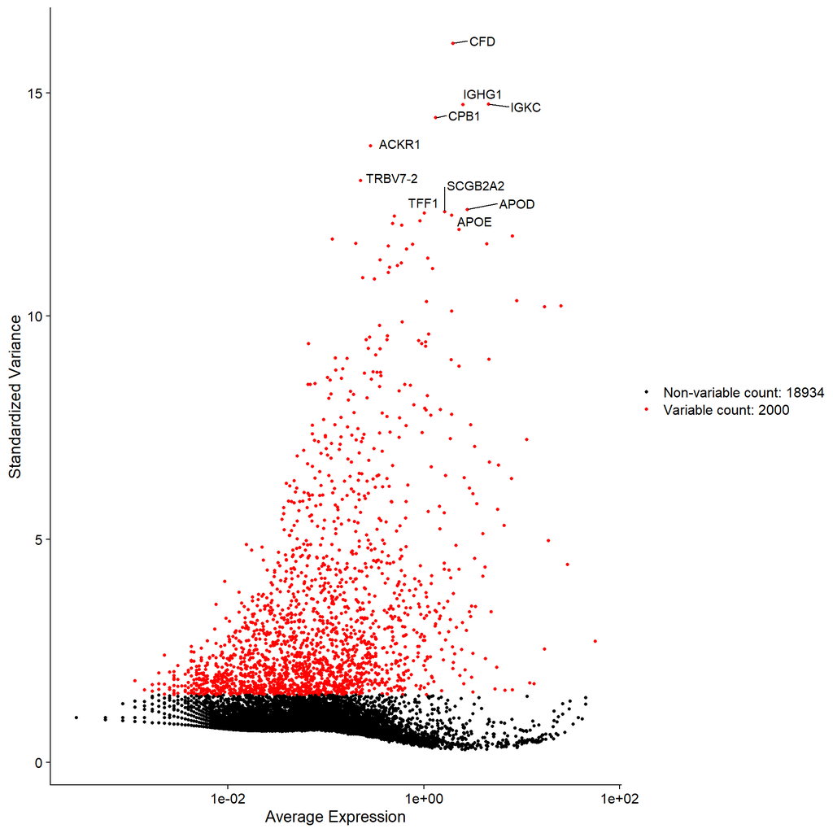

```r
### Find the top 2000 most variable genes for PCA analysis
bassez1 <- FindVariableFeatures(object=bassez1, selection.method = "vst",
                            nfeatures = 2000)

### Plot variable features with labels
### Identify the 10 most highly variable genes
top10 <- head(VariableFeatures(bassez1), 10)
labels <- VariableFeaturePlot(bassez1)
LabelPoints(plot = labels, points = top10, repel = TRUE)
```

### Scale the data

Next, we apply a linear transformation (‘scaling’) that is a standard pre-processing step prior to dimensional reduction techniques like PCA. The `ScaleData()` function:

1. Shifts the expression of each gene, so that the mean expression across cells is 0
2. Scales the expression of each gene, so that the variance across cells is 1. This step gives equal weight in downstream analyses, so that highly-expressed genes do not dominate
3. The results of this are stored in **[[“RNA”]]@scale.data**

**NOTE**

By default `ScaleData()` will only scale the identified 2,000 genes unless specified using the `"features = all.genes"` argument.

```r
### Now scale
#all.genes <- rownames(x = bassez1)
bassez1 <- ScaleData(object = bassez1,
#                     features = all.genes,
                     verbose = FALSE,
                     vars.to.regress = unlist(strsplit(params$qcs_vars_regress, split = ",", fixed = T)))
```

## 1.3 - Identify the cell cycle phase for each cell

Score the cell cycle phase of each cell. This is done by calculating the G2M marker score with the `CellCycleScoring()` function provided in the *seurat package*.

```r
### [1] Create G2M marker gene list (i.e. genes associated with the G2M phase of the
### cell cycle using Seurat's built-in cc.genes (cell cycle) genes list
g2m.genes <- cc.genes$g2m.genes
g2m <- rownames(bassez1)[rownames(bassez1) %in% g2m.genes]

### [2] Calculate G2M marker module score.
bassez1 <- CellCycleScoring(bassez1,
                            s.features = cc.genes$s.genes, ### Genes associated with s-phase
                            g2m.features = g2m.genes, ### Genes associated with G2M phase
                            set.ident = TRUE)
```